# Practical Machine Learning Course Project

# Overview

The goal of this project is to predict the manner of exercise, represented by the “classe” variable. The following document is a report that outlines the model building process, cross validation, and sample error. The prediction model will also be used to predict 20 different test cases. The data for this project come from this source: http://web.archive.org/web/20161224072740/http:/groupware.les.inf.puc-rio.br/har

# Prepping the Environment

```r
# Loading the Appropriate Packages
library(knitr)
library(rpart)
library(rpart.plot)
library(caret)
library(corrplot)
library(rattle)
library(randomForest)
library(gbm)
library(ggplot2)

# Setting the seed
set.seed(1)
```

# Data Prep and Cleaning

The data was first loaded into R and partitioned into train and test datasets.

```r
# Importing the training and testing datasets
training <- read.csv("https://d396qusza40orc.cloudfront.net/predmachlearn/pml-training.csv")

testing <- read.csv("https://d396qusza40orc.cloudfront.net/predmachlearn/pml-testing.csv")

# Creating a partition in the training dataset
index <- createDataPartition(training$classe, p=.7, list=FALSE)
trainset <- training[index,]
testset <- training[-index,]

str(trainset)
```

```
## 'data.frame':    13737 obs. of  160 variables:
##  $ X                       : int  2 3 4 5 7 8 9 10 11 12 ...
##  $ user_name               : Factor w/ 6 levels "adelmo","carlitos",..: 2 2 2 2 2 2 2 2 2 2 ...
##  $ raw_timestamp_part_1    : int  1323084231 1323084231 1323084232 1323084232 1323084232 1323084232 1323084232 1323084232 1323084232 1323084232 ...
##  $ raw_timestamp_part_2    : int  808298 820366 120339 196328 368296 440390 484323 484434 500302 528316 ...
##  $ cvtd_timestamp          : Factor w/ 20 levels "02/12/2011 13:32",..: 9 9 9 9 9 9 9 9 9 9 ...
##  $ new_window              : Factor w/ 2 levels "no","yes": 1 1 1 1 1 1 1 1 1 1 ...
##  $ num_window              : int  11 11 12 12 12 12 12 12 12 12 ...
##  $ roll_belt               : num  1.41 1.42 1.48 1.48 1.42 1.42 1.43 1.45 1.45 1.43 ...
##  $ pitch_belt              : num  8.07 8.07 8.05 8.07 8.09 8.13 8.16 8.17 8.18 8.18 ...
##  $ yaw_belt                : num  -94.4 -94.4 -94.4 -94.4 -94.4 -94.4 -94.4 -94.4 -94.4 -94.4 ...
##  $ total_accel_belt        : int  3 3 3 3 3 3 3 3 3 3 ...
##  $ kurtosis_roll_belt      : Factor w/ 397 levels "","-0.016850",..: 1 1 1 1 1 1 1 1 1 1 ...
##  $ kurtosis_picth_belt     : Factor w/ 317 levels "","-0.021887",..: 1 1 1 1 1 1 1 1 1 1 ...
##  $ kurtosis_yaw_belt       : Factor w/ 2 levels "","#DIV/0!": 1 1 1 1 1 1 1 1 1 1 ...
```

[output cut: 86 more lines]

A quick scan of the dataset shows some variables have low variability (i.e., near zero variance) and other variables have many missing values. The data was therefore cleaned by removing these variables. The identification variables at the beginning of the dataset were removed as well.

```r
# Removing variables with near zero variance
trainset <- trainset[, -nearZeroVar(trainset)]
testset <- testset[, -nearZeroVar(testset)]

# Removing variables will all missing dataset
na_rm <- sapply(trainset, function(x) mean(is.na(x))) > .95
trainset <- trainset[, na_rm==FALSE]
testset <- testset[,na_rm==FALSE]

# Removing ID variables
trainset <- trainset[, -(1:6)]
testset <- testset[, -(1:6)]
```

These procedures reduced the number of variables from 160 to 53.

# Correlations

A correlation matrix was generated to see if many variables are correlated amongst themselves.

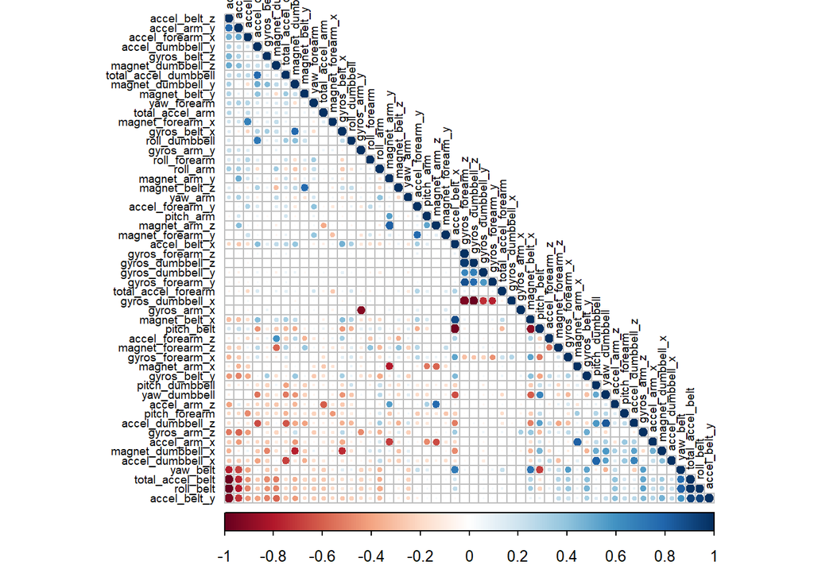

```r
corrplot(cor(trainset[, -53]), order="FPC", method="circle", type="lower", tl.cex=.6, tl.col=rgb(0,0,0))
```

# Prediction Models

## Decision Tree Model

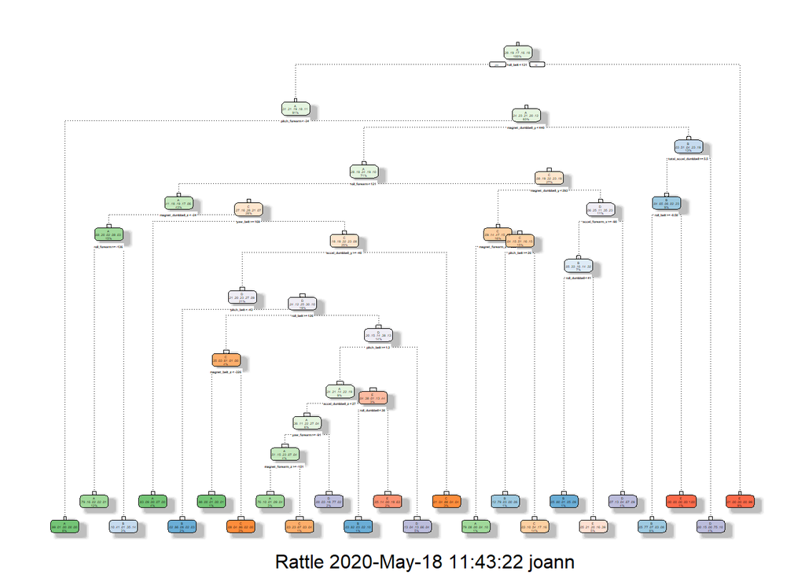

```r
# Creating the model
fit_tree <- rpart(classe ~. ,data=trainset, method="class")
fancyRpartPlot(fit_tree)
```

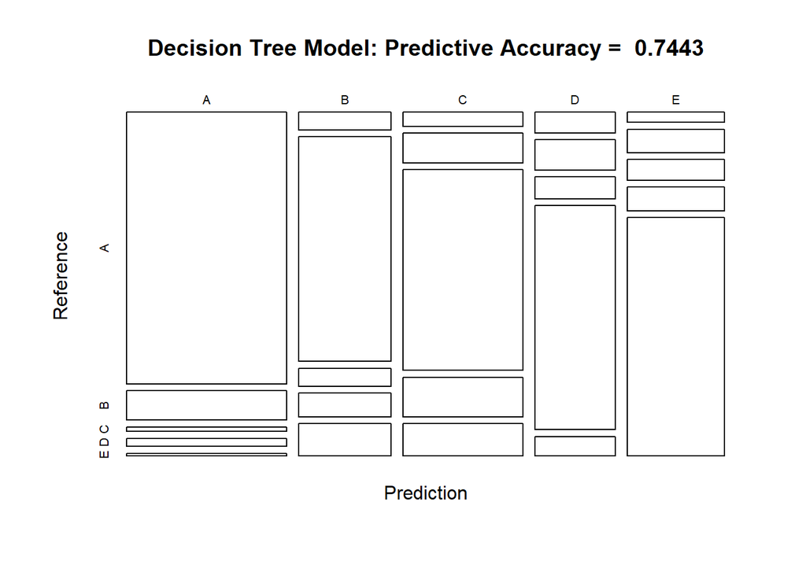

```r
# Testing the model on the test dataset
predict_tree <- predict(fit_tree, newdata=testset, type="class")
matrix_tree <- confusionMatrix(predict_tree, testset$classe)

# Plotting the predictive accuracy of the Decision Tree Model
plot(matrix_tree$table, col=matrix_tree$byClass,
     main=paste("Decision Tree Model: Predictive Accuracy = ",round(matrix_tree$overall[1],4)))
```

The predictive accuracy of the Decision Tree Model is 74.43%.

## Generalized Boosted Model

```r
# Creating the model
control <- trainControl(method="repeatedcv", number=5, repeats=2)
fit_GBM <- train(classe ~., data=trainset, method="gbm",
                 trControl=control, verbose=FALSE)
fit_GBM$finalModel
```

```
## A gradient boosted model with multinomial loss function.
## 150 iterations were performed.
## There were 52 predictors of which 52 had non-zero influence.
```

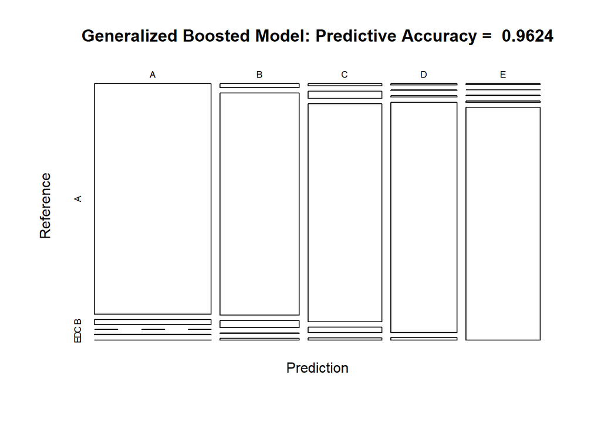

```r
# Testing the model on the test dataset
predict_GBM <- predict(fit_GBM, newdata=testset)
matrix_GBM <- confusionMatrix(predict_GBM, testset$classe)

# Plotting the predictive accuracy of the Decision Tree Model
plot(matrix_GBM$table, col=matrix_GBM$byClass,
     main=paste("Generalized Boosted Model: Predictive Accuracy = ",round(matrix_GBM$overall[1],4)))
```

The predictive accuracy of the Generalized Boosted Model is 96.24%, which is much higher than the Decision Tree Model.

## Random Forest

```r
# Creating the model
control_RF <- trainControl(method="repeatedcv", number=5, repeats=2)
fit_RF <- train(classe ~., data=trainset, method="rf",
                 trControl=control_RF, verbose=FALSE)
fit_RF$finalModel
```

```
##
## Call:
##  randomForest(x = x, y = y, mtry = param$mtry, verbose = FALSE)
##                Type of random forest: classification
##                      Number of trees: 500
## No. of variables tried at each split: 27
##
##         OOB estimate of  error rate: 0.75%
## Confusion matrix:
##      A    B    C    D    E class.error
## A 3896    8    1    0    1 0.002560164
## B   18 2629    9    1    1 0.010910459
## C    0   13 2373   10    0 0.009599332
## D    0    2   24 2224    2 0.012433393
## E    0    0    5    8 2512 0.005148515
```

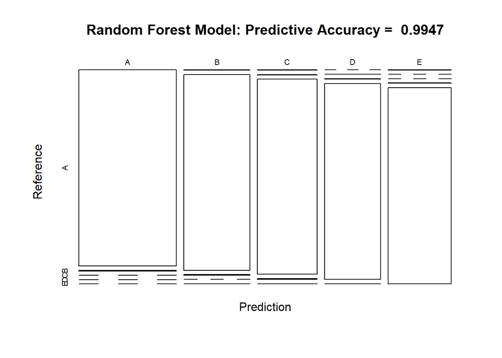

```r
# Testing the model on the test dataset
predict_RF <- predict(fit_RF, newdata=testset)
matrix_RF <- confusionMatrix(predict_RF, testset$classe)

# Plotting the predictive accuracy of the Decision Tree Model
plot(matrix_RF$table, col=matrix_RF$byClass,
     main=paste("Random Forest Model: Predictive Accuracy = ",round(matrix_RF$overall[1],4)))
```

The predictive accuracy of the Random Forest Model is 99.47%, which is the highest of the 3 models.

# Final Test

The performance of the different models in terms of accuracy are as follows:

1. Random Forest Model: **99.47%**
2. Generalized Boosted Model: **96.24%**
3. Decision Tree Model: **74.43%**

The Random Forest Model was used to predict the *classe* variable in the test dataset.

```r
predict_test <- predict(fit_RF, newdata=testing)
predict_test
```

```
##  [1] B A B A A E D B A A B C B A E E A B B B
## Levels: A B C D E
```